# Text similarity

Initialize

```python
import numpy as np
import scipy
import pandas as pd
from sentence_transformers import SentenceTransformer
from sklearn.metrics.pairwise import cosine_similarity
from scipy.stats import spearmanr
import matplotlib.pyplot as plt
import seaborn as sns

## using bert model
model = SentenceTransformer('bert-base-nli-mean-tokens')
```

## Words similarity

```python
from sematch.semantic.similarity import WordNetSimilarity
wns = WordNetSimilarity()
## Computing English word similarity using Li method
wns.word_similarity('dog', 'cat', 'li') # 0.449327301063
```

```
0.44932730106286095
```

## Text semantic similarity

**Steps**

1. Transform a sentence to a set of vectors based on it's semantic meaning
2. Calculate vectors' similarity

**Step1:**  
Transform a sentence to a set of vectors based on it's semantic meaning  
We need to choose an algorithm to realize it

**Sentence-Transformers Methods**  
**Measuring text similarity using BERT**

Reference:  
https://arxiv.org/abs/1810.04805 (Original article, Google AI Language)  
https://www.analyticsvidhya.com/blog/2021/05/measuring-text-similarity-using-bert/ (A tutorial)  
https://zhuanlan.zhihu.com/p/51413773 (A tutorial)

BERT: Pre-training of Deep Bidirectional Transformers for Language Understanding  
Key words: **pre-training, deep (learning), bidirectional, transformers, language understanding**

pre-training: Language model for improving natural language processing tasks;  
deep: has 12 layers;  
bidrectional: can predict the mask word before and after;  
transformer: transform sentence to vectors;  
landuage understanding: can understanding the sentence's semantic meaning.

Return a vector comprising 768 digits.

(Note: there are many language understanding models, BERT is just one of them. Each model has different performance and is focused on specific apects. Choosing a suitable model is tricky, though)

**Step2:**  
Compute similarity  
Cosine distance is commonly used in NLP area

### Basic example

```python
## try with these sentenses
sen = [
    "Three years later, the coffin was still full of Jello.",
    "The fish dreamed of escaping the fishbowl and into the toilet where he saw his friend go.",
    "The person box was packed with jelly many dozens of months later.",
    "He found a leprechaun in his walnut shell."
]

#Encoding:
sen_embeddings = model.encode(sen)
```

```python
## visualize
sen_embeddings = pd.DataFrame(sen_embeddings)
sen_embeddings
#sen_embeddings.shape
```

|  | 0 | 1 | 2 | 3 | 4 | 5 | 6 | 7 | 8 | 9 | ... | 758 | 759 | 760 | 761 | 762 | 763 | 764 | 765 | 766 | 767 |
| --- | --- | --- | --- | --- | --- | --- | --- | --- | --- | --- | --- | --- | --- | --- | --- | --- | --- | --- | --- | --- | --- |
| 0 | 0.074462 | 0.863697 | 0.179464 | -0.203804 | 0.057756 | -0.384835 | 0.199586 | 0.946925 | -0.136268 | 0.272824 | ... | -0.186612 | -0.462163 | -0.815507 | 0.356777 | 0.459308 | -0.681461 | 0.475528 | 0.773440 | 1.724749 | -0.180275 |
| 1 | -0.371463 | 0.972901 | 1.083993 | 0.063879 | 0.074646 | -0.112302 | 1.289930 | -0.119037 | 0.434924 | -0.634571 | ... | 0.302572 | -0.156195 | -1.133458 | -0.777743 | 0.482236 | 0.152577 | 0.539164 | -0.255213 | -0.275937 | 0.035759 |
| 2 | -0.502982 | 0.794986 | -0.124025 | 0.281558 | 0.699608 | -0.594939 | -0.758811 | 1.445383 | -0.373572 | -0.204854 | ... | -0.345968 | -1.635824 | -0.801724 | 0.360416 | 0.317240 | -0.866174 | 0.354610 | 0.144063 | 0.970375 | -0.179116 |
| 3 | -0.213119 | 1.017494 | -0.883276 | 0.065447 | 0.294869 | 0.184252 | 0.181841 | 0.494823 | -0.658762 | 0.080747 | ... | -0.467178 | 0.121336 | -0.626418 | -0.066623 | 0.160511 | -0.667240 | 0.189539 | 0.737104 | 0.194692 | -0.301113 |

4 rows × 768 columns

Sentence transformer retures 768 dims for each sentence

```python
# calculate cosine similarity for sentence 0:
sen_embeddings = np.array(sen_embeddings)
cosine_similarity([sen_embeddings[0]],sen_embeddings[1:])
```

```
array([[0.33088923, 0.72192585, 0.55483645]], dtype=float32)
```

### Play with open data

Amazon food reviews  
https://www.kaggle.com/datasets/snap/amazon-fine-food-reviews?resource=download  
Dataset description: This dataset consists of reviews of fine foods from amazon. The data span a period of more than 10 years, including all ~500,000 reviews up to October 2012. Reviews include **product and user information, ratings, and a plain text review. It also includes reviews from all other Amazon categories.**

```python
## Load data
df_review_temp = pd.read_csv('D:/Download/archive/Reviews.csv')
## to reduce the amount of calculation, chose 500 reviewers to analyze
df_review = df_review_temp.iloc[:500,:]
```

```python
## visualize the data
df_review.iloc[:3,:]
```

|  | Id | ProductId | UserId | ProfileName | HelpfulnessNumerator | HelpfulnessDenominator | Score | Time | Summary | Text |
| --- | --- | --- | --- | --- | --- | --- | --- | --- | --- | --- |
| 0 | 1 | B001E4KFG0 | A3SGXH7AUHU8GW | delmartian | 1 | 1 | 5 | 1303862400 | Good Quality Dog Food | I have bought several of the Vitality canned d... |
| 1 | 2 | B00813GRG4 | A1D87F6ZCVE5NK | dll pa | 0 | 0 | 1 | 1346976000 | Not as Advertised | Product arrived labeled as Jumbo Salted Peanut... |
| 2 | 3 | B000LQOCH0 | ABXLMWJIXXAIN | Natalia Corres "Natalia Corres" | 1 | 1 | 4 | 1219017600 | "Delight" says it all | This is a confection that has been around a fe... |

```python
df_review.iloc[0,-1]
```

```
'I have bought several of the Vitality canned dog food products and have found them all to be of good quality. The product looks more like a stew than a processed meat and it smells better. My Labrador is finicky and she appreciates this product better than  most.'
```

**A hypothesis: customer reviews' similarity correlate with customer scoring's similarity**  
i.e. reviews' semantic similarity can predict the similarity of the score

#### Calculate reviews' semantic similarity

```python
## calculate text vectors
df_review_embedding = model.encode(df_review.iloc[:,-1])
```

```python
## visualize
# df_review_embedding[0,:]
```

```python
## a loop to create review similarity rdm
df_review_rdm = np.zeros((len(df_review_embedding),len(df_review_embedding)))
df_review_rdm = pd.DataFrame(df_review_rdm)
for i in range(0,len(df_review_embedding)):
    for j in range(0,len(df_review_embedding)):
        df_review_rdm.iloc[i,j] = cosine_similarity([df_review_embedding[i],df_review_embedding[j]])[0,1]
        df_review_rdm.iloc[j,i] = cosine_similarity([df_review_embedding[i],df_review_embedding[j]])[0,1]
```

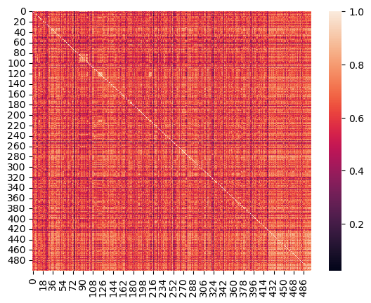

```python
## visualize
sns.heatmap(df_review_rdm)
```

#### Calculate scores' similarity

```python
df_score_rdm = np.zeros((len(df_review_embedding),len(df_review_embedding)))
df_score_rdm = pd.DataFrame(df_score_rdm)
for i in range(0,len(df_review_embedding)):
    for j in range(0,len(df_review_embedding)):
        df_score_rdm.iloc[i,j] = 5 - abs(df_review.iloc[i,6] - df_review.iloc[j,6])
        df_score_rdm.iloc[j,i] = 5 - abs(df_review.iloc[i,6] - df_review.iloc[j,6])
## I use euclidean distance here
```

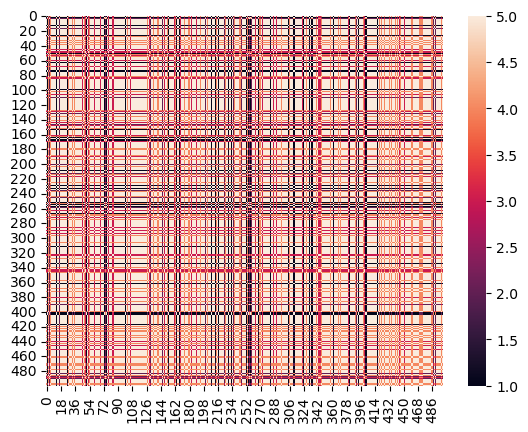

```python
## visualize
sns.heatmap(df_score_rdm)
```

Define some useful functions

```python
## write a function to melt dependent data
def melt_df(df_temp):
    df_size = len(df_temp)
    df_ls = list()
    for i in range(0,df_size):
        for j in range(i+1,df_size):
            df_ls.append(df_temp.iloc[j,i])
    return df_ls

## write a function to do permutation test on dependent data
def permu_test_new(df1, df2, n_times):
    df_per_corr = list()
    for i in range(n_times):
        df1_size = len(df1)
        df1_vec = list()
        for j in range(0, df1_size):
            np_temp = np.array(df1.iloc[(j+1):,j])
            np.random.shuffle(np_temp)
            for k in range(len(np_temp)):
                df1_vec.append(np_temp[k])
        df2_size = len(df2)
        df2_vec = list()
        for j in range(0, df2_size):
            np_temp = np.array(df2.iloc[(j+1):,j])
            np.random.shuffle(np_temp)
            for k in range(len(np_temp)):
                df2_vec.append(np_temp[k])
        df_per_r_temp = spearmanr(df1_vec,df2_vec)[0]
        df_per_corr.append(df_per_r_temp)
    return df_per_corr
```

Calculate spearman correlation between score RDM and review RDM

```python
score_vec = melt_df(df_score_rdm)
review_vec = melt_df(df_review_rdm)
# calculate spearman r
review_corr = spearmanr(score_vec, review_vec)
review_corr
```

```
SpearmanrResult(correlation=0.21756001375847686, pvalue=0.0)
```

Permutation test

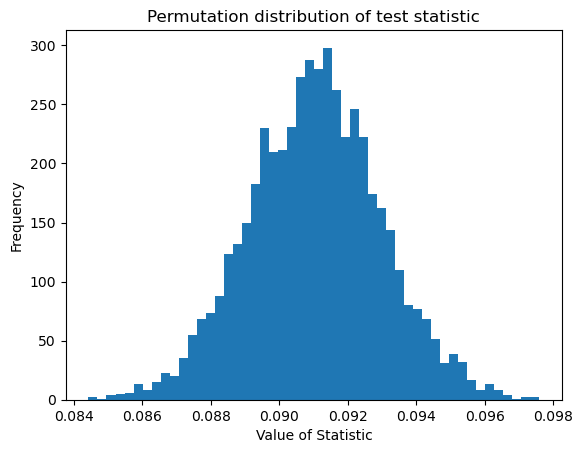

```python
df_per_corr = permu_test_new(df_score_rdm, df_review_rdm, 5000)
## plot the distribution
# import matplotlib.pyplot as plt
plt.hist(df_per_corr, bins=50)
plt.title("Permutation distribution of test statistic")
plt.xlabel("Value of Statistic")
plt.ylabel("Frequency")
plt.show()
```

The correlation value is higher than chance level

#### Correlation with other variables

##### With "summary" (review summary)

Expect a high correlation since the summary should have similiar meaning as review

```python
## calculate text vectors
df_summary_embedding = model.encode(df_review.iloc[:,-2])
df_summary_rdm = np.zeros((len(df_summary_embedding),len(df_summary_embedding)))
df_summary_rdm = pd.DataFrame(df_summary_rdm)
for i in range(0,len(df_summary_embedding)):
    for j in range(0,len(df_summary_embedding)):
        df_summary_rdm.iloc[i,j] = cosine_similarity([df_summary_embedding[i],df_summary_embedding[j]])[0,1]
        df_summary_rdm.iloc[j,i] = cosine_similarity([df_summary_embedding[i],df_summary_embedding[j]])[0,1]

summary_vec = melt_df(df_summary_rdm)
summary_review_corr = spearmanr(summary_vec, review_vec)
summary_review_corr
```

```
SpearmanrResult(correlation=0.19226558107262495, pvalue=0.0)
```

##### With profilename

Expect no correlation between these vairables since they don't relate to each other

```python
## calculate text vectors
df_profile_embedding = model.encode(df_review.iloc[:,3])
df_profile_rdm = np.zeros((len(df_profile_embedding),len(df_profile_embedding)))
df_profile_rdm = pd.DataFrame(df_profile_rdm)
for i in range(0,len(df_profile_embedding)):
    for j in range(0,len(df_profile_embedding)):
        df_profile_rdm.iloc[i,j] = cosine_similarity([df_profile_embedding[i],df_profile_embedding[j]])[0,1]
        df_profile_rdm.iloc[j,i] = cosine_similarity([df_profile_embedding[i],df_profile_embedding[j]])[0,1]

profile_vec = melt_df(df_profile_rdm)
profile_review_corr = spearmanr(profile_vec, review_vec)
profile_review_corr
```

```
SpearmanrResult(correlation=0.04275385039204683, pvalue=1.447357228492148e-51)
```

In summary, the the semantic similarity can predict the similarity of scoring.  
This may because high evaluations often contain positive description, and sentence transformer can sensitively detect it.